# Dados de commits no github.

Valter Lucena

9 de julho de 2018

Os dados utilizados nesta análise são referentes à quantidade de pessoas que editaram um arquivo com determinada extensão no [Github](http://github.com), com o objetivo de entender um pouco mais sobre a popularidade das linguagens de programação.

# Dados

Primeiramente, vamos importar nossos dados, que são uma amostra da atividade global do github.

```r
commits = readr::read_csv(here("data/github-users-committing-filetypes.csv"))
commits %>% names(.)
```

```
## [1] "file_extension" "month_day"      "the_month"      "the_year"
## [5] "users"
```

Agora, vamos ver quais são as extensões de arquivos que temos informações, e quais as mais utilizadas.

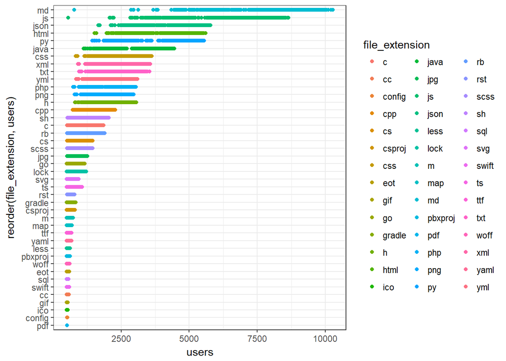

```r
commits %>%
  ggplot(aes(x = reorder(file_extension, users),
             y = users,
             colour = file_extension)) +
  geom_point() +
  coord_flip()
```

Para esta análise, consideraremos apenas as linguagens Python (.py) e Java (.java). Iremos necessitar, também, do dia da semana de cada observação.

```r
escolhidos = commits %>%
  filter(file_extension %in% c("py", "java")) %>%
  mutate(date = paste(the_year, the_month, month_day, sep = "-") %>% as.Date(.)) %>%
  mutate(weekday = weekdays(as.Date(date))) %>%
  mutate(is_weekend = ifelse(weekday %in% c("sábado", "domingo"), TRUE, FALSE))
```

Após as modificações na base de dados, vamos observar como se comporta a quantidade de usuários que utilizam essas linguagens ao longo do tempo. A base de dados utilizada contém dados referentes aos anos de 2016 e 2017.

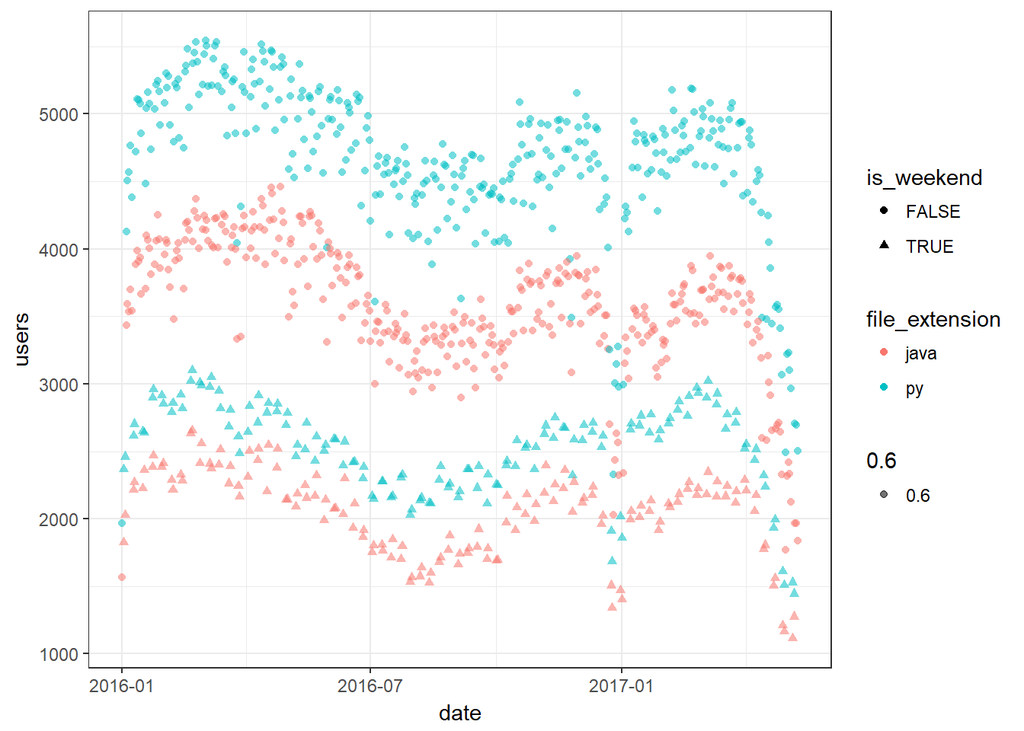

```r
escolhidos %>%
  ggplot(aes(x = date,
             y = users,
             color = file_extension,
             shape = is_weekend,
             alpha = .6)) +
  geom_point()
```

No gráfico acima, cada observação é referente à quantidade de usuários da linguagem durante um dia desse intervalo de tempo. Observamos que Python possui mais usuários que Java, mesmo durante os fins de semana, e que esse número, um pouco depois do início de 2017, começa a decrescer para ambas as linguagens durante todos os dias da semana.

# Para as linguagens escolhidas, há uma diferença significativa na sua popularidade durante a semana e durante o fim de semana? Essa diferença é grande?

Vejamos, inicialmente, o número de usuários de cada linguagem durante a semana e durante o fim de semana separadamente.

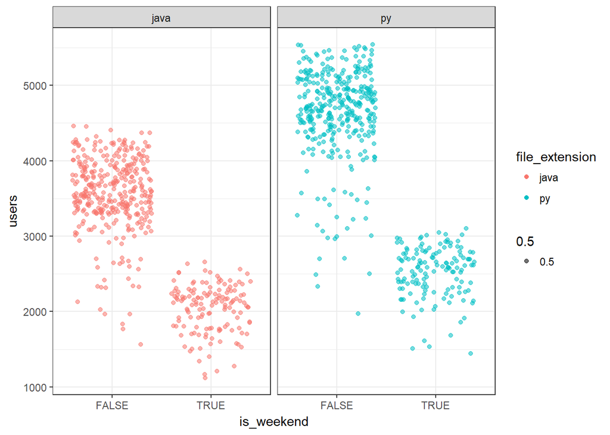

```r
escolhidos %>%
  ggplot(aes(x = is_weekend,
             y = users,
             colour = file_extension,
             alpha = .5)) +
  geom_jitter() +
  facet_grid(~ file_extension)
```

Observamos que ambas as linguagens são mais utilizadas durante a semana, sendo Python a linguagem mais utilizada, inclusive nos fins de semana. Essa diferença é alta, e pode ser notada visualmente pelo agrupamento da maioria das observações das duas linguagens no local onde as observações são referentes apenas aos dias da semana.

Porém, essa conclusão é precipitada, devido ao fato de possuirmos somente uma amostra da atividade dos usuários. Então, utilizaremos uma técnica de inferência chamada de **bootstrap** para coletar informações da amostra e utilizar como base para criar nossas conclusões sobre a popularidade das linguagens. Utilizaremos a mediana da quantidade de usuários da linguagem como estatística para isso.

[figure not shown]

```r
boots.pyfds = escolhidos %>%
  filter(file_extension == "py",
         is_weekend) %>%
  bootstrap(median(users),
            R = 10000)

boots.javafds = escolhidos %>%
  filter(file_extension == "java",
         is_weekend) %>%
  bootstrap(median(users),
            R = 10000)

ci.mediana.pyfds = boots.pyfds %>%
  CI.percentile(probs = c(0.025, 0.975)) # 95%

ci.mediana.javafds = boots.javafds %>%
  CI.percentile(probs = c(0.025, 0.975))

boots.py = escolhidos %>%
  filter(file_extension == "py",
         !is_weekend) %>%
  bootstrap(median(users),
            R = 10000)

boots.java = escolhidos %>%
  filter(file_extension == "java",
         !is_weekend) %>%
  bootstrap(median(users),
            R = 10000)

ci.mediana.py = boots.py %>%
  CI.percentile(probs = c(0.025, 0.975)) # 95%

ci.mediana.java = boots.java %>%
  CI.percentile(probs = c(0.025, 0.975))

medianas = data.frame(rbind(ci.mediana.py,
                            ci.mediana.pyfds,
                            ci.mediana.java,
                            ci.mediana.javafds))
medianas$medida = c("py fds",
                    "py semana",
                    "java fds",
                    "java semana")

medianas %>%
  ggplot(aes(x = medida,
             ymin = X2.5.,
             ymax = X97.5.)) +
  geom_errorbar(width = .095)
```

## Existe uma diferença significativa entre a popularidade das duas linguagens nos fins de semana?

Ainda utilizando boostrap, vamos utilizar o desvio padrão para analisar a diferença entre a popularidade das linguagens durante o fim de semana.

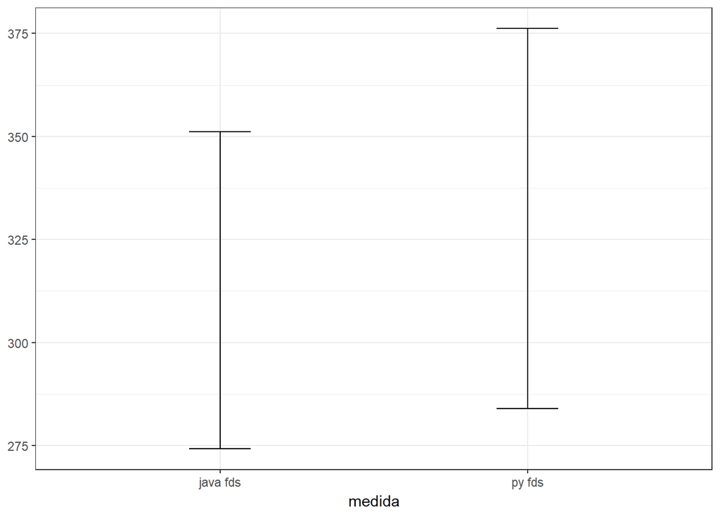

```r
py.fds = escolhidos %>%
  filter(file_extension == "py",
         is_weekend)

java.fds = escolhidos %>%
  filter(file_extension == "java",
         is_weekend)

sd.ci.pyfds = py.fds %>%
  bootstrap(sd(users)) %>%
  CI.percentile(probs = c(0.025, 0.975))

sd.ci.javafds = java.fds %>%
  bootstrap(sd(users)) %>%
  CI.percentile(probs = c(0.025, 0.975))

sds = data.frame(rbind(sd.ci.pyfds,
                sd.ci.javafds))

sds$medida = c("py fds", "java fds")

sds %>%
  ggplot(aes(x = medida,
             ymin = X2.5.,
             ymax = X97.5.)) +
  geom_errorbar(width = .2)
```